# Chapter12 様々なグラフを作る

## 12.1 折れ線グラフ

### 12.1.1 マーカーの種類と色を設定する

- 折れ線グラフの描画
  - **`matplotlib.pyplot.plot()`**
- マーカーの種類の設定
  - 引数に **`marker="指定子"`** を指定する
    - マーカーの種類 matplotlib.markers
- マーカーの色の設定
  - 引数に **`markerfacecolor="指定子"`** を指定する
    - 指定できる色は11.2.1節の色の指定と同じ

#### マーカーの種類と色の設定例

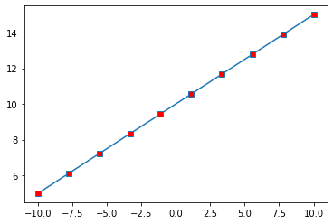

```python
import matplotlib.pyplot as plt
import numpy as np
## Jupyter Notebookの場合必要
%matplotlib inline

## X軸データ
## -10から10まで等間隔のデータ取得（10個）
x = np.linspace(-10, 10, 10)
## Y軸データ
y = 0.5 * x + 10

# データx,yをグラフにプロット
# マーカーを四角、マーカーの色を赤に設定
plt.plot(x, y, marker="s", markerfacecolor="r")

# グラフ表示
plt.show()
```

### 12.1.2 線のスタイルと色を設定する

- 線のスタイルの設定
  - 引数に **`linestyle="指定子"`** を指定する
    - 主な線のスタイルの種類
      - **`"-"`** ：実線
      - **`"--"`** ：破線
      - **`"-."`** ：破線（点入り）
      - **`":"`** ：点線
- 線の色の設定
  - 引数に **`color="指定子"`** を指定する
    - 指定できる色は11.2.1節のプロットの色の指定と同じ

#### 線のスタイルと色の設定例

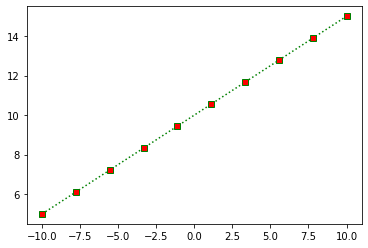

```python
import matplotlib.pyplot as plt
import numpy as np
## Jupyter Notebookの場合必要
%matplotlib inline

## X軸データ
## -10から10まで等間隔のデータ取得（10個）
x = np.linspace(-10, 10, 10)
## Y軸データ
y = 0.5 * x + 10

# データx,yをグラフにプロット
# 線のスタイルを点線、線の色を緑に設定
# マーカーを四角、マーカーの色を赤に設定
plt.plot(x, y, linestyle=":", color="g", marker="s", markerfacecolor="r")

# グラフ表示
plt.show()
```

## 12.2 棒グラフ

### 12.2.1 棒グラフを作成する

- 棒グラフの描画
  - **`matplotlib.pyplot.bar(横軸の値, 縦軸の値)`**

#### 棒グラフ作成の例

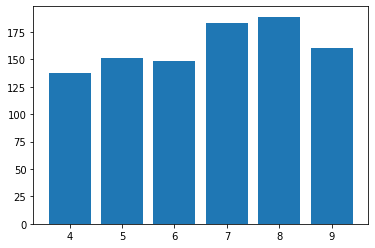

```python
import numpy as np
import matplotlib.pyplot as plt
%matplotlib inline

## 横軸の値を持つリスト
x = [4, 5, 6, 7, 8, 9]
## 横軸の値を持つリスト
y = [138, 151, 149, 183, 189, 160]

# 棒グラフを作成
plt.bar(x, y)

plt.show()
```

### 12.2.2 横軸にラベルを設定する

- 棒グラフの横軸にラベルを付ける方法
  - 折れ線グラフやほかのグラフでの方法と異なる
  - **`matplotlib.pyplot.bar()`** に引数 **`tick_label`** としてラベルが入っているリストを渡す

#### 横軸にラベルを設定した例

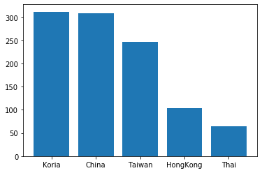

```python
import numpy as np
import matplotlib.pyplot as plt
%matplotlib inline

## 横軸の値を持つリスト
x = [1, 2, 3, 4, 5]
## 縦軸の値を持つリスト
y = [312, 308, 247, 103, 65]
## 横軸のラベルを持つリスト
labels = ["Koria", "China", "Taiwan", "HongKong", "Thai"]

# 棒グラフを作成
plt.bar(x, y, tick_label=labels)

plt.show()
```

### 12.2.3 積み上げ棒グラフを作成する

- 積み上げ棒グラフ
  - 2系統以上のデータを同じ項目に関して積み上げたグラフ
  - **`matplotlib.pyplot.bar()`** に引数 **`bottom`** として、下側のデータ列を渡す
- bottomによる設定を繰り返すことで積み上げを重ねることができる
- **`pyplot.legend(("系統1のラベル", "系統2のラベル", ...))`** とすることで、系統ラベル（凡例）の設定が可能

#### 積み上げ棒グラフの作成例

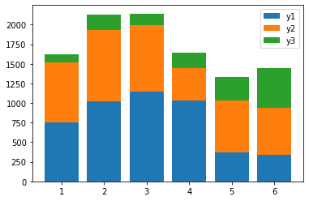

```python
import numpy as np
import matplotlib.pyplot as plt
%matplotlib inline

## 横軸の値を持つリスト
x = [1, 2, 3, 4, 5, 6]
## 縦軸の値を持つリストその1
y1 = [749, 1017, 1149, 1028, 368, 342]
## 縦軸の値を持つリストその2
y2 = [773, 912, 843, 419, 668, 601]
## 縦軸の値を持つリストその3
y3 = [100, 200, 150, 200, 300, 500]

# 積み上げ棒グラフを作成
plt.bar(x, y1)
# y1の値の上にy2の値を積み上げる
plt.bar(x, y2, bottom=y1)

# y1の値の上にy2の値を積み上げたy12の上にy3の値を積み上げる
y12 = np.array(y1) + np.array(y2)
plt.bar(x, y3, bottom=y12)

# 凡例を作成することも可能
plt.legend(("y1", "y2", "y3"))
plt.show()
```